# Project Linear Regression: Boston House Price Prediction

# **Marks: 30**

Welcome to the project on Linear Regression. We will use the Boston house price data for the exercise.

## Problem Statement

The problem on hand is to predict the housing prices of a town or a suburb based on the features of the locality provided to us. In the process, we need to identify the most important features in the dataset. We need to employ techniques of data preprocessing and build a linear regression model that predicts the prices for us.

## Data Information

Each record in the database describes a Boston suburb or town. The data was drawn from the Boston Standard Metropolitan Statistical Area (SMSA) in 1970. Detailed attribute information can be found below-

Attribute Information (in order):

- **CRIM:** per capita crime rate by town
- **ZN:** proportion of residential land zoned for lots over 25,000 sq.ft.
- **INDUS:** proportion of non-retail business acres per town
- **CHAS:** Charles River dummy variable (= 1 if tract bounds river; 0 otherwise)
- **NOX:** nitric oxides concentration (parts per 10 million)
- **RM:** average number of rooms per dwelling
- **AGE:** proportion of owner-occupied units built before 1940
- **DIS:** weighted distances to five Boston employment centers
- **RAD:** index of accessibility to radial highways
- **TAX:** full-value property-tax rate per 10,000 dollars
- **PTRATIO:** pupil-teacher ratio by town
- **LSTAT:** %lower status of the population
- **MEDV:** Median value of owner-occupied homes in 1000 dollars

### Let us start by importing the required libraries

```python
# import libraries for data manipulation
import pandas as pd
import numpy as np

# import libraries for data visualization
import matplotlib.pyplot as plt
import seaborn as sns
from statsmodels.graphics.gofplots import ProbPlot

# import libraries for building linear regression model
from statsmodels.formula.api import ols
import statsmodels.api as sm
from sklearn.linear_model import LinearRegression

# import library for preparing data
from sklearn.model_selection import train_test_split

# import library for data preprocessing
from sklearn.preprocessing import MinMaxScaler

import warnings
warnings.filterwarnings("ignore")
```

### Read the dataset

```python
df = pd.read_csv("Boston.csv")
df.head()
```

|  | CRIM | ZN | INDUS | CHAS | NOX | RM | AGE | DIS | RAD | TAX | PTRATIO | LSTAT | MEDV |
| --- | --- | --- | --- | --- | --- | --- | --- | --- | --- | --- | --- | --- | --- |
| 0 | 0.00632 | 18.0 | 2.31 | 0 | 0.538 | 6.575 | 65.2 | 4.0900 | 1 | 296 | 15.3 | 4.98 | 24.0 |
| 1 | 0.02731 | 0.0 | 7.07 | 0 | 0.469 | 6.421 | 78.9 | 4.9671 | 2 | 242 | 17.8 | 9.14 | 21.6 |
| 2 | 0.02729 | 0.0 | 7.07 | 0 | 0.469 | 7.185 | 61.1 | 4.9671 | 2 | 242 | 17.8 | 4.03 | 34.7 |
| 3 | 0.03237 | 0.0 | 2.18 | 0 | 0.458 | 6.998 | 45.8 | 6.0622 | 3 | 222 | 18.7 | 2.94 | 33.4 |
| 4 | 0.06905 | 0.0 | 2.18 | 0 | 0.458 | 7.147 | 54.2 | 6.0622 | 3 | 222 | 18.7 | 5.33 | 36.2 |

**Observations**

- The price of the house indicated by the variable MEDV is the target variable and the rest are the independent variables based on which we will predict house price.

### Get information about the dataset using the info() method

```python
df.info()
```

```
<class 'pandas.core.frame.DataFrame'>
RangeIndex: 506 entries, 0 to 505
Data columns (total 13 columns):
 #   Column   Non-Null Count  Dtype
---  ------   --------------  -----
 0   CRIM     506 non-null    float64
 1   ZN       506 non-null    float64
 2   INDUS    506 non-null    float64
 3   CHAS     506 non-null    int64
 4   NOX      506 non-null    float64
 5   RM       506 non-null    float64
 6   AGE      506 non-null    float64
 7   DIS      506 non-null    float64
 8   RAD      506 non-null    int64
 9   TAX      506 non-null    int64
 10  PTRATIO  506 non-null    float64
 11  LSTAT    506 non-null    float64
 12  MEDV     506 non-null    float64
dtypes: float64(10), int64(3)
memory usage: 51.5 KB
```

**Observations**

- There are a total of 506 non-null observations in each of the columns. This indicates that there are no missing values in the data.
- Every column in this dataset is numeric in nature.

### Let's now check the summary statistics of this dataset

#### **Question 1:** Write the code to find the summary statistics and write your observations based on that. (1 Mark)

```python
#write your code here
df.describe()
```

|  | CRIM | ZN | INDUS | CHAS | NOX | RM | AGE | DIS | RAD | TAX | PTRATIO | LSTAT | MEDV |
| --- | --- | --- | --- | --- | --- | --- | --- | --- | --- | --- | --- | --- | --- |
| count | 506.000000 | 506.000000 | 506.000000 | 506.000000 | 506.000000 | 506.000000 | 506.000000 | 506.000000 | 506.000000 | 506.000000 | 506.000000 | 506.000000 | 506.000000 |
| mean | 3.613524 | 11.363636 | 11.136779 | 0.069170 | 0.554695 | 6.284634 | 68.574901 | 3.795043 | 9.549407 | 408.237154 | 18.455534 | 12.653063 | 22.532806 |
| std | 8.601545 | 23.322453 | 6.860353 | 0.253994 | 0.115878 | 0.702617 | 28.148861 | 2.105710 | 8.707259 | 168.537116 | 2.164946 | 7.141062 | 9.197104 |
| min | 0.006320 | 0.000000 | 0.460000 | 0.000000 | 0.385000 | 3.561000 | 2.900000 | 1.129600 | 1.000000 | 187.000000 | 12.600000 | 1.730000 | 5.000000 |
| 25% | 0.082045 | 0.000000 | 5.190000 | 0.000000 | 0.449000 | 5.885500 | 45.025000 | 2.100175 | 4.000000 | 279.000000 | 17.400000 | 6.950000 | 17.025000 |
| 50% | 0.256510 | 0.000000 | 9.690000 | 0.000000 | 0.538000 | 6.208500 | 77.500000 | 3.207450 | 5.000000 | 330.000000 | 19.050000 | 11.360000 | 21.200000 |
| 75% | 3.677083 | 12.500000 | 18.100000 | 0.000000 | 0.624000 | 6.623500 | 94.075000 | 5.188425 | 24.000000 | 666.000000 | 20.200000 | 16.955000 | 25.000000 |
| max | 88.976200 | 100.000000 | 27.740000 | 1.000000 | 0.871000 | 8.780000 | 100.000000 | 12.126500 | 24.000000 | 711.000000 | 22.000000 | 37.970000 | 50.000000 |

**Observations:**

- Per Capita Crime Rate has some outliers in the high end: 75th percentile is 3.66 per capita town rate, while max is 88.976 (which, in this context, is absurdly high and represents a very dangerous town). These outliers seem to have a big effect on the standard deviation and mean, which would otherwise be smaller (IQR has a smaller range, with 75th percentile being at 3.6, 25th percentile at 0.08 and mean at 3.6). Aside from this outlier observation, it seems that the top 25% CRIM rates are a lot higher in general: the bottom 50% are below .26, and that ramps up to 3.67 for 75th percentile. Only a few towns are very dangerous, while most aren't close to them.
- ZN has an interesting distribution. Up to 50% of the houses have no proportion zoned for lots (0). Afterwardsm the 75th percentile has 12.5 and the max is 100. This can be explained because most of the plots are not over 25,000 sq ft, and ZN only has a proportion value for plots over 25,000 sq ft. This column will have a positive skew, but that will be explored afterwards in the univariate analysis.
- INDUS explains the proportion of non-retail business acres per town. This will also have highly different values depending on the town. Because of this, the range is wide, as expected. With minimums of 0.46 in towns which don't have a lot of non-retail business acres, up to 27.74 acres in towns which do. In this column, the values seem to have a more even distribution: they ramp up from 0.46 to 5.19 in the 25th percentile, then 9.69 in the 50th, 18.1 in 75th and finally 27.74 at max. Values don't seem to have as many outliers, the mean and std deviation represent this.
- CHAS is a dummy variable which is either 0 or 1. The mean in 0.07 and the std deviation is 0.25, which means most values are 0 and only a few are 1. When we see the percentiles this can be confirmed: values are 0 up to the 75th percentile.
- NOX has a very small range, which makes sense because it explains the nitric oxides concentration parts per 10 mllion, and higher values than those presented would not make sense unless extreme air pollution.
- Rooms per dwelling has a marked difference between households, with the lowest 25% at only 5.8 rooms and the highest at 8.78 rooms. Even the minimum is at 3.56, even the zones with the lowest values in RM have a close to 4 rooms per household on average. The standard deviation is really low, and the mean coincides almost perfectly with the 50th percentile. This means that RM most likely has a normal distribution and few (if any) outliers which heavily skew the data.
- AGE is different from the last column discussed. It has a very wide range: minimum at 2.9 and maximum at 100. It seems that this minimum value is an outlier, as the quarter percentiles (25th, 50th 75th and max) ramp up quickly from this minimum, until it reaches 100 as maximum. From this, we can infer that a lot of towns have a high proportion of owner-occupied units built before 1940.
- DIS seems to have an outlier in the maximum value, the distance between minimum, 25th percentile, 50th percentile and 75th is pretty similar: ramping up from 1.12 to 5.18. And then the maximum value is 12.1265. Despite this value, the standard deviation is still 2.1 and the mean is 3.79, these outliers do affect the stats but not as much as in other cases (like CRIM). Most towns have a similar weighted distance to five Boston employment centers.
- The accessibility to Radial Highways has the same value (24) in the 75th percentile and the max: a lot of the towns have a high accessibility index to these highways. The lowest values (from minimum to 50th percentile) have a range of 1 to 5: most towns have a way lower accessibility index that the top 25%.
- TAX has a wide value range, ranging from 187 all the way to 711. The difference between 0-50th percentile is not that big, but there's a 2x jump to the 75th percentile. Seems like a lot of towns have a low tax rate, and then a lot of towns (but less, the top 25%) have a high tax rate. As will be seen later, this column has a bimodal distribution representing this.
- PTRATIO doesn't have a wide range, and seems to have an outlier in the minimum. The difference between the minimum and the 25th percentile is bigger than between the max and the 25th. The low outlier probably affects the mean and std, but it shouldn't be a low enough value to drastically affect the distribution. Because of this, the distribution is more than likely negatively skewed. Most towns have a high pupil-teacher ratio, with a few outliers in the low side (and in general a pretty similar range when taking all towns into account).
- LSTAT seems to have outliers in the maximum: the 75th percentile is 16.95% of lower status, while the max is 37.97%. This outlier affects the std and mean heavily, as well as the range. The distribution seems to have most (75% atleast) of the values between 1.73% and 16.95%, but the outliers cause it to go all the way until 37.97%; this column's distribution is positively skewed.
- MEDV: Finally, the median values of homes. This column also seems to have high outliers: the lowest 75% ranges from 5k dollars to 25k dollars, but then the maximum duplicates the 75th percentile and is at 50k dollars. This is a big enough outlier to affect the std and mean of the column. There is also an outlier in the minimum value: 5k dollars jumps to 17k dollars in the 25th percentile. Despite these outliers, the IQR is not that big (25k at 75th percentile and 17k at 25th). This distribution probably has most values packed in the middle (this IQR range) with a few outliers in both extremes. Most towns have a similar, middle range home value, with a few towns having very cheap house values and others having very expensive values.

Before performing the modeling, it is important to check the univariate distribution of the variables.

### Check the distribution of the variables

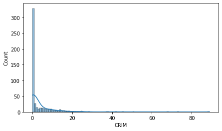

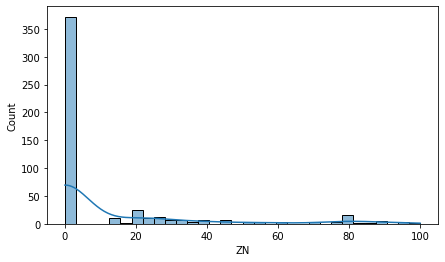

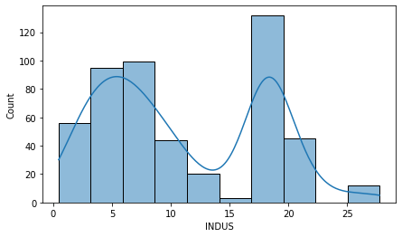

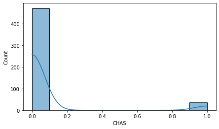

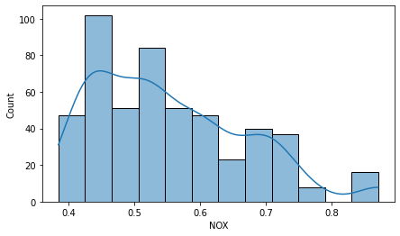

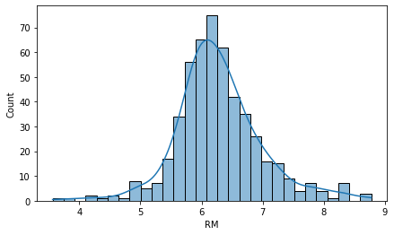

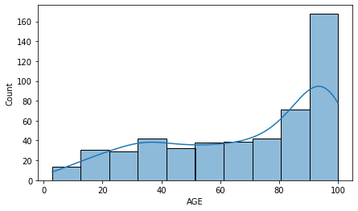

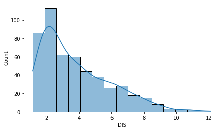

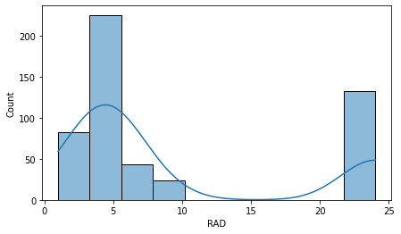

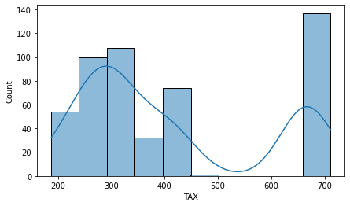

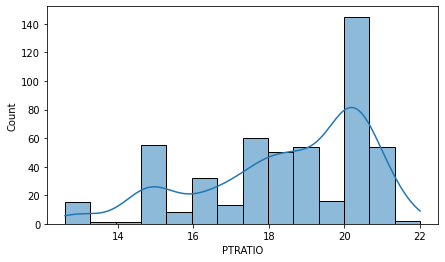

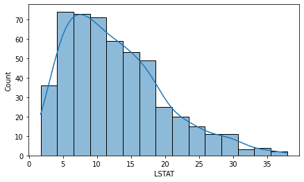

[1 more figures not shown]

```python
# let's plot all the columns to look at their distributions
for i in df.columns:
    plt.figure(figsize=(7, 4))
    sns.histplot(data=df, x=i, kde = True)
    plt.show()
```

**Observations**

- **The variables CRIM and ZN are positively skewed.** This suggests that most of the areas have lower crime rates and most residential plots are under the area of 25,000 sq. ft.
- **The variable CHAS, with only 2 possible values 0 and 1, follows a binomial distribution**, and the majority of the houses are away from Charles river (CHAS = 0).
- The distribution of the variable AGE suggests that many of the owner-occupied houses were built before 1940.
- **The variable DIS** (average distances to five Boston employment centers) **has a nearly exponential distribution**, which indicates that most of the houses are closer to these employment centers.
- **The variables TAX and RAD have a bimodal distribution.**, indicating that the tax rate is possibly higher for some properties which have a high index of accessibility to radial highways.
- The dependent variable MEDV seems to be slightly right skewed.

As the dependent variable is sightly skewed, we will apply a **log transformation on the 'MEDV' column** and check the distribution of the transformed column.

```python
df['MEDV_log'] = np.log(df['MEDV'])
```

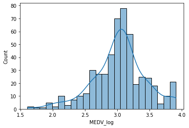

```python
sns.histplot(data=df, x='MEDV_log', kde = True)
```

**Observations**

- The log-transformed variable (**MEDV_log**) appears to have a **nearly normal distribution without skew**, and hence we can proceed.

Before creating the linear regression model, it is important to check the bivariate relationship between the variables. Let's check the same using the heatmap and scatterplot.

### Bivariate Analysis

#### Let's check the correlation using the heatmap

### **Question 2** (3 Marks):

- **Write the code to plot the correlation heatmap between the variables (1 Mark)**
- **Write your observations (2 Marks)**

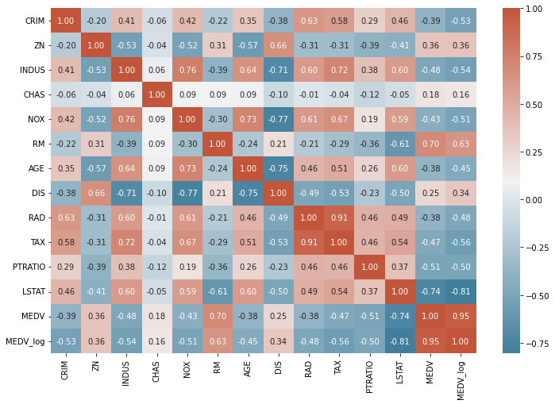

```python
plt.figure(figsize=(12,8))
cmap = sns.diverging_palette(230, 20, as_cmap=True)
sns.heatmap(df.corr(),annot=True,fmt='.2f',cmap=cmap ) #write your code here
plt.show()
```

**Observations:**

- Crime rates are somewhat positively correlated (>=0.4) with Radial Highways Accesibility, tax value rate, INDUS, NOX, and LSTAT. While correlation does not imply causation, it is still interesting to analyze how crime rates in towns go up as this other variables do. Despite this, there's no significant (>0.7) positive correlation between crime and other variables. Another interesting observation regarding crime is that there's a negative (-0.53) correlation between this column and Median Household value (when log scaled). This is very interesting, as towns with higher value households seem to also have lower per capita crime rate.
- ZN seems to have a high correlation with DIS and a high negative correlation with AGE. Towns with residential lots over 25,000 sq ft also seem to have a higher distance to employment centers and not as many owner-occupied units built before 1940. We can't make assumptions without further analysis.
- INDUS has a significant (>0.7) correlation with NOX. We will want to analyze this as we want to avoid multicollinearity. As the proportion of non-retail business acres increases, so does the nitric oxides concentration. This correlation could possibly be explained because of the pollution caused by having more businesses, but we can't make assumptions without further analysis. It also has a significant negative correlation with distances to the 5 Boston employment centers. The INDUS NOX relation should be further analyzed for multicollinearity avoidance.
- CHAS does not seem to have a high (negative or positive) correlation with any other variable.
- NOX once again is significantly correlated with INDUS, as explained previously. It also has a significant positive correlation with AGE, we should explore this to avoid multicollinearity. NOX has a significant negative correlation with distance to employment centers (the higher the distance, the lower PPM of nitric oxides), this is an interesting relationship.
- RM has a significant correlation with the Median household values in towns. This makes sense, as the average number of rooms increasing should increase the median household value.
- AGE, as explained previously, has a significant correlation with NOX. It also has a significant negative correlation with DIS, the bigger the proportion of owner-occupied old houses, the lower the weighted distances to employment centers.
- DIS, as explained previously, has a significant correlation with INDUS, NOX and AGE. These correlations where explained in previous points.
- RAD has a very significant correlation with TAX (0.91). This is very close to being a 1:1 correlation, and we really want to avoid multicollinearity. The higher the accessibility index to radial highways, the higher the full-value property-tax rate, we need to further analyze this relation to avoid making assumptions.
- TAX has a significant positive correlation with both INDUS and RAD (with a very high correlation in this case). This column might cause multicollinearity which we want to avoid.
- PTRATIO does not have significant correlation to any other column.
- LSTAT has signficant negative correlation to the household value. The higher the % of lower status population, the lower the median household value, which makes sense.
- Median household value has a high positive correlation with RM (and negative with LSTAT), as explained before. It also has a very high (0.95) correlation with MEDV_LOG, but this should be the case as it is just a log transformation of the same column. MEDV_log follows the same logic as MEDV, but its correlation with RM is somewhat lower (drops from significant range).

Now, we will visualize the relationship between the pairs of features having significant correlations.

### Visualizing the relationship between the features having significant correlations (> 0.7)

### **Question 3** (6 Marks):

- **Create a scatter plot to visualize the relationship between the features having significant correlations (>0.7) (3 Marks)**
- **Write your observations from the plots (3 Marks)**

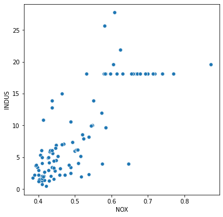

```python
# scatterplot to visualize the relationship between NOX and INDUS
plt.figure(figsize=(6, 6))
sns.scatterplot(x="NOX", y="INDUS", data=df) #write you code here
plt.show()
```

**Observations:**

- It seems that the proportion of non-retail business acres increase as the nitric oxides concentration does.
- While both seem to increase togethere, the relation is not perfect as can be seen when NOX is between 0.6 and 1.
- It seems that NOX concentration does increase with businesses, which could possibly be attributed to pollution.

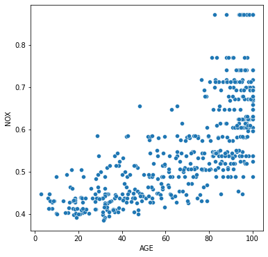

```python
# scatterplot to visualize the relationship between AGE and NOX
plt.figure(figsize=(6, 6))
sns.scatterplot(x="AGE", y="NOX", data=df) #Write your code here
plt.show()
```

**Observations:**

- There seems to be a positive, almost exponential relation between AGE and NOX.
- It seems that, the bigger the proportion of owner-occupied houses built before 1940 is, the larger the Nitric Oxides concentration.
- It is possible that the more polluted areas are located in established towns with a large proportion of owner houses built before 1940.

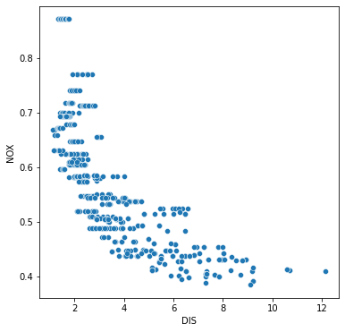

```python
# scatterplot to visualize the relationship between DIS and NOX
plt.figure(figsize=(6, 6))
sns.scatterplot(x="DIS", y="NOX", data=df) #Write your code here
plt.show()
```

**Observations:**

- There seems to be a negative relation between DIS and NOX.
- It is very accelerated, almost looks like a negative exponential.
- It seems that, the farther the town is to boston employment centers, the lesser the NOX measure.
- This could be attributed to towns with closer employment centers having more pollution.
- We can clearly see a relationship from the previous graph and some of the following ones: established towns have employment centers and higher NOX (which can represent higher pollution).

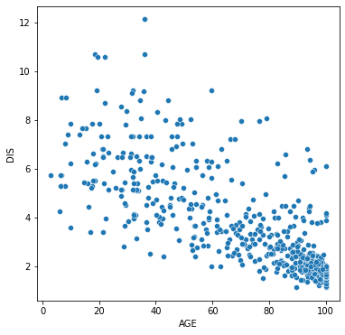

```python
# scatterplot to visualize the relationship between AGE and DIS
plt.figure(figsize=(6, 6))
sns.scatterplot(x = 'AGE', y = 'DIS', data = df)
plt.show()
```

**Observations:**

- The distance of the houses to the Boston employment centers appears to decrease moderately as the the proportion of the old houses increase in the town. It is possible that the Boston employment centers are located in the established towns where proportion of owner-occupied units built prior to 1940 is comparatively high.

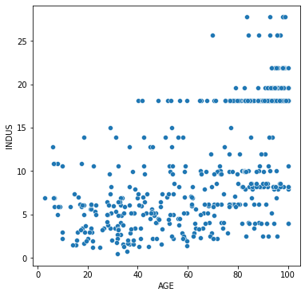

```python
# scatterplot to visualize the relationship between AGE and INDUS
plt.figure(figsize=(6, 6))
sns.scatterplot(x = 'AGE', y = 'INDUS', data = df)
plt.show()
```

**Observations:**

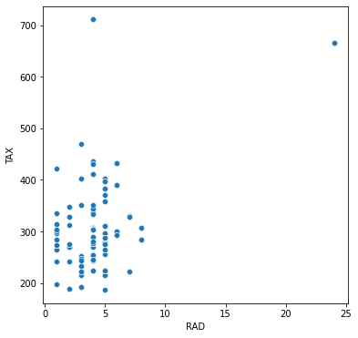

```python
# scatterplot to visulaize the relationship between RAD and TAX
plt.figure(figsize=(6, 6))
sns.scatterplot(x = 'RAD', y = 'TAX', data = df)
plt.show()
```

**Observations:**

- The correlation between RAD and TAX is very high. But, no trend is visible between the two variables. This might be due to outliers.

Let's check the correlation after removing the outliers.

```python
# remove the data corresponding to high tax rate
df1 = df[df['TAX'] < 600]
# import the required function
from scipy.stats import pearsonr
# calculate the correlation
print('The correlation between TAX and RAD is', pearsonr(df1['TAX'], df1['RAD'])[0])
```

```
The correlation between TAX and RAD is 0.24975731331429202
```

So the high correlation between TAX and RAD is due to the outliers. The tax rate for some properties might be higher due to some other reason.

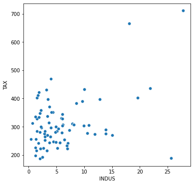

```python
# scatterplot to visualize the relationship between INDUS and TAX
plt.figure(figsize=(6, 6))
sns.scatterplot(x = 'INDUS', y = 'TAX', data = df)
plt.show()
```

**Observations:**

- The tax rate appears to increase with an increase in the proportion of non-retail business acres per town. This might be due to the reason that the variables TAX and INDUS are related with a third variable.

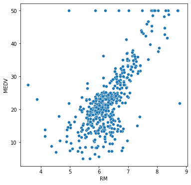

```python
# scatterplot to visulaize the relationship between RM and MEDV
plt.figure(figsize=(6, 6))
sns.scatterplot(x = 'RM', y = 'MEDV', data = df)
plt.show()
```

**Observations:**

- The price of the house seems to increase as the value of RM increases. This is expected as the price is generally higher for more rooms.
- There are a few outliers in a horizontal line as the MEDV value seems to be capped at 50.

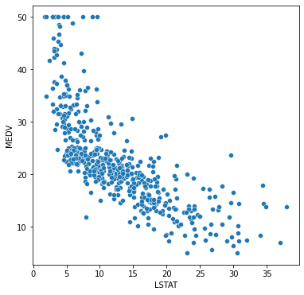

```python
# scatterplot to visulaize the relationship between LSTAT and MEDV
plt.figure(figsize=(6, 6))
sns.scatterplot(x = 'LSTAT', y = 'MEDV', data = df)
plt.show()
```

**Observations:**

- The price of the house tends to decrease with an increase in LSTAT. This is also possible as the house price is lower in areas where lower status people live.
- There are few outliers and the data seems to be capped at 50.

We have seen that the variables LSTAT and RM have a linear relationship with the dependent variable MEDV. Also, there are significant relationships among a few independent variables, which is not desirable for a linear regression model. Let's first split the dataset.

### Split the dataset

Let's split the data into the dependent and independent variables and further split it into train and test set in a ratio of 70:30 for train and test set.

```python
# separate the dependent and independent variable
Y = df['MEDV_log']
X = df.drop(columns = {'MEDV', 'MEDV_log'})

# add the intercept term
X = sm.add_constant(X)
```

```python
# splitting the data in 70:30 ratio of train to test data
X_train, X_test, y_train, y_test = train_test_split(X, Y, test_size=0.30 , random_state=1)
```

Next, we will check the multicollinearity in the train dataset.

### Check for Multicollinearity

We will use the Variance Inflation Factor (VIF), to check if there is multicollinearity in the data.

Features having a VIF score > 5 will be dropped/treated till all the features have a VIF score < 5

```python
from statsmodels.stats.outliers_influence import variance_inflation_factor

# function to check VIF
def checking_vif(train):
    vif = pd.DataFrame()
    vif["feature"] = train.columns

    # calculating VIF for each feature
    vif["VIF"] = [
        variance_inflation_factor(train.values, i) for i in range(len(train.columns))
    ]
    return vif


print(checking_vif(X_train))
```

```
    feature         VIF
0     const  535.372593
1      CRIM    1.924114
2        ZN    2.743574
3     INDUS    3.999538
4      CHAS    1.076564
5       NOX    4.396157
6        RM    1.860950
7       AGE    3.150170
8       DIS    4.355469
9       RAD    8.345247
10      TAX   10.191941
11  PTRATIO    1.943409
12    LSTAT    2.861881
```

**Observations:**

- There are two variables with a high VIF - RAD and TAX. Let's remove TAX as it has the highest VIF values and check the multicollinearity again.

#### **Question 4:** Drop the column 'TAX' from the training data and check if multicollinearity is removed? (1 Mark)

```python
# create the model after dropping TAX
X_train = X_train.drop(columns={"TAX"})

# check for VIF
print(checking_vif(X_train))
```

```
    feature         VIF
0     const  532.025529
1      CRIM    1.923159
2        ZN    2.483399
3     INDUS    3.270983
4      CHAS    1.050708
5       NOX    4.361847
6        RM    1.857918
7       AGE    3.149005
8       DIS    4.333734
9       RAD    2.942862
10  PTRATIO    1.909750
11    LSTAT    2.860251
```

Now, we will create the linear regression model as the VIF is less than 5 for all the independent variables, and we can assume that multicollinearity has been removed between the variables.

#### **Question 5:** Write the code to create the linear regression model and print the model summary. Write your observations from the model. (3 Marks)

```python
# create the model
model1 = sm.OLS(y_train, X_train) #write your code here
model1=model1.fit()
# get the model summary
model1.summary()
```

OLS Regression Results

| Dep. Variable: | MEDV_log | R-squared: | 0.769 |
| --- | --- | --- | --- |
| Model: | OLS | Adj. R-squared: | 0.761 |
| Method: | Least Squares | F-statistic: | 103.3 |
| Date: | Tue, 23 Nov 2021 | Prob (F-statistic): | 1.40e-101 |
| Time: | 16:33:16 | Log-Likelihood: | 76.596 |
| No. Observations: | 354 | AIC: | -129.2 |
| Df Residuals: | 342 | BIC: | -82.76 |
| Df Model: | 11 |  |  |
| Covariance Type: | nonrobust |  |  |

|  | coef | std err | t | P>\|t\| | [0.025 | 0.975] |
| --- | --- | --- | --- | --- | --- | --- |
| const | 4.6324 | 0.243 | 19.057 | 0.000 | 4.154 | 5.111 |
| CRIM | -0.0128 | 0.002 | -7.445 | 0.000 | -0.016 | -0.009 |
| ZN | 0.0010 | 0.001 | 1.425 | 0.155 | -0.000 | 0.002 |
| INDUS | -0.0004 | 0.003 | -0.148 | 0.883 | -0.006 | 0.005 |
| CHAS | 0.1196 | 0.039 | 3.082 | 0.002 | 0.043 | 0.196 |
| NOX | -1.0598 | 0.187 | -5.675 | 0.000 | -1.427 | -0.692 |
| RM | 0.0532 | 0.021 | 2.560 | 0.011 | 0.012 | 0.094 |
| AGE | 0.0003 | 0.001 | 0.461 | 0.645 | -0.001 | 0.002 |
| DIS | -0.0503 | 0.010 | -4.894 | 0.000 | -0.071 | -0.030 |
| RAD | 0.0076 | 0.002 | 3.699 | 0.000 | 0.004 | 0.012 |
| PTRATIO | -0.0452 | 0.007 | -6.659 | 0.000 | -0.059 | -0.032 |
| LSTAT | -0.0298 | 0.002 | -12.134 | 0.000 | -0.035 | -0.025 |

| Omnibus: | 30.699 | Durbin-Watson: | 1.923 |
| --- | --- | --- | --- |
| Prob(Omnibus): | 0.000 | Jarque-Bera (JB): | 83.718 |
| Skew: | 0.372 | Prob(JB): | 6.62e-19 |
| Kurtosis: | 5.263 | Cond. No. | 2.09e+03 |

Notes:  
[1] Standard Errors assume that the covariance matrix of the errors is correctly specified.  
[2] The condition number is large, 2.09e+03. This might indicate that there are  
strong multicollinearity or other numerical problems.

**Observations:**

- Adjusted R-squared is lower than R-squared, there are probably some insignificant variables that we should drop.
- The adjusted R-squared is 0.761, it is probably possible to get a better fit than this (since it can go all the way to 1).
- If we check the p value and the confidence intervals, we can conclude that:
  - CRIM, CHAS, NOX, RM, DIS, RAD, PTRATIO and LSTAT have a p-value < 0.05. If our Ho is that our feature is not significant, then we can reject this Ho, thus this features are significant to predicting our dependent variable MEDV_log.
    - ZN, INDUS and AGE have a p-value greater than 0.05. Thus we fail to reject Ho, which means these variables are not significant for predicting our dependent variable MEDV_log and should be dropped.
- The standard error for CRIM, ZN, INDUS, CHAS, RM, AGE, DIS, RAD, PTRATIO and LSTAT is very low (<0.1), the lower the std error, the more accurate the coeficients.
- The Confidence Intervals let us know where the coefficients will fall 95% of the time. For our significant variables:
  - The CRIM coefficient will fall in between -0.016 and -0.009 95% of the time.
  - The CHAS coefficent will fall between 0.043 and 0.196 95% of the time.
  - The NOX coefficient will fall between -1.427 and -0.692 95% of the time.
  - The RM coefficient will fall between 0.012 and 0.094 95% of the time.
  - The DIS coefficent will fall between -0.071 and -0.03 95% of the time.
  - The RAD coefficient will fall between 0.004 and 0.012 95% of the time.
  - The PTRATIO coefficient will fall between -0.059 and -0.032 95% of the time.
  - The LSTAT coefficient will fall between -0.035 and -0.025 95% of the time.

#### **Question 6:** Drop insignificant variables from the above model and create the regression model again. (2 Marks)

### Examining the significance of the model

It is not enough to fit a multiple regression model to the data, it is necessary to check whether all the regression coefficients are significant or not. Significance here means whether the population regression parameters are significantly different from zero.

From the above it may be noted that the regression coefficients corresponding to ZN, AGE, and INDUS are not statistically significant at level α = 0.05. In other words, the regression coefficients corresponding to these three are not significantly different from 0 in the population. Hence, we will eliminate the three features and create a new model.

```python
# create the model after dropping columns 'MEDV', 'MEDV_log', 'TAX', 'ZN', 'AGE', 'INDUS' from df dataframe
Y = df['MEDV_log']
X = df.drop(columns={"MEDV", "MEDV_log", "TAX", "ZN", "AGE", "INDUS"}) #write your code here
X = sm.add_constant(X)

#splitting the data in 70:30 ratio of train to test data
X_train, X_test, y_train, y_test = train_test_split(X, Y, test_size=0.30 , random_state=1)

# create the model
model2 = sm.OLS(y_train, X_train) #write your code here
model2=model2.fit()
# get the model summary
model2.summary()
```

OLS Regression Results

| Dep. Variable: | MEDV_log | R-squared: | 0.767 |
| --- | --- | --- | --- |
| Model: | OLS | Adj. R-squared: | 0.762 |
| Method: | Least Squares | F-statistic: | 142.1 |
| Date: | Tue, 23 Nov 2021 | Prob (F-statistic): | 2.61e-104 |
| Time: | 16:48:02 | Log-Likelihood: | 75.486 |
| No. Observations: | 354 | AIC: | -133.0 |
| Df Residuals: | 345 | BIC: | -98.15 |
| Df Model: | 8 |  |  |
| Covariance Type: | nonrobust |  |  |

|  | coef | std err | t | P>\|t\| | [0.025 | 0.975] |
| --- | --- | --- | --- | --- | --- | --- |
| const | 4.6494 | 0.242 | 19.242 | 0.000 | 4.174 | 5.125 |
| CRIM | -0.0125 | 0.002 | -7.349 | 0.000 | -0.016 | -0.009 |
| CHAS | 0.1198 | 0.039 | 3.093 | 0.002 | 0.044 | 0.196 |
| NOX | -1.0562 | 0.168 | -6.296 | 0.000 | -1.386 | -0.726 |
| RM | 0.0589 | 0.020 | 2.928 | 0.004 | 0.019 | 0.098 |
| DIS | -0.0441 | 0.008 | -5.561 | 0.000 | -0.060 | -0.028 |
| RAD | 0.0078 | 0.002 | 3.890 | 0.000 | 0.004 | 0.012 |
| PTRATIO | -0.0485 | 0.006 | -7.832 | 0.000 | -0.061 | -0.036 |
| LSTAT | -0.0293 | 0.002 | -12.949 | 0.000 | -0.034 | -0.025 |

| Omnibus: | 32.514 | Durbin-Watson: | 1.925 |
| --- | --- | --- | --- |
| Prob(Omnibus): | 0.000 | Jarque-Bera (JB): | 87.354 |
| Skew: | 0.408 | Prob(JB): | 1.07e-19 |
| Kurtosis: | 5.293 | Cond. No. | 690. |

Notes:  
[1] Standard Errors assume that the covariance matrix of the errors is correctly specified.

**Observations:**

- We can see that the **R-squared value has decreased by 0.002**, since we have removed variables from the model, whereas the **adjusted R-squared value has increased by 0.001**, since we removed statistically insignificant variables only.

Now, we will check the linear regression assumptions.

### Check the below linear regression assumptions

1. **Mean of residuals should be 0**
2. **No Heteroscedasticity**
3. **Linearity of variables**
4. **Normality of error terms**

#### **Question 7:** Write the code to check the above linear regression assumptions and provide insights. (4 Marks)

#### Check for mean residuals

```python
residuals = model2.resid
residuals.mean()
```

```
-3.723951467344381e-15
```

**Observations:**

- A linear regression assumption is that the mean of the residuals should be 0. Here, the mean of residuals is extremely close to 0, so the assumption is satisfied.

#### Check for homoscedasticity

- Homoscedasticity - If the residuals are symmetrically distributed across the regression line, then the data is said to homoscedastic.
- Heteroscedasticity - If the residuals are not symmetrically distributed across the regression line, then the data is said to be heteroscedastic. In this case, the residuals can form a funnel shape or any other non-symmetrical shape.
- We'll use `Goldfeldquandt Test` to test the following hypothesis with alpha = 0.05:
  - Null hypothesis: Residuals are homoscedastic
  - Alternate hypothesis: Residuals have heteroscedastic

```python
from statsmodels.stats.diagnostic import het_white
from statsmodels.compat import lzip
import statsmodels.stats.api as sms
```

```python
name = ["F statistic", "p-value"]
test = sms.het_goldfeldquandt(y_train, X_train)
lzip(name, test)
```

```
[('F statistic', 1.0835082923425285), ('p-value', 0.3019012006766869)]
```

**Observations:**

- The p-value is significantly greater than 0.05, therefore we fail to reject the null hypothesis. This means that the residuals are not heteroscedastic, meeting another assumption.

#### Linearity of variables

It states that the predictor variables must have a linear relation with the dependent variable.

To test the assumption, we'll plot residuals and fitted values on a plot and ensure that residuals do not form a strong pattern. They should be randomly and uniformly scattered on the x-axis.

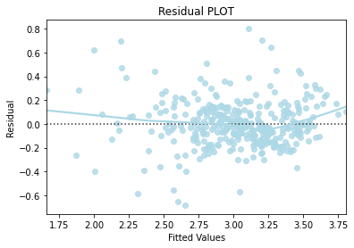

```python
# predicted values
fitted = model2.fittedvalues

# sns.set_style("whitegrid")
sns.residplot(x = fitted, y = residuals, color="lightblue", lowess=True) #write your code here
plt.xlabel("Fitted Values")
plt.ylabel("Residual")
plt.title("Residual PLOT")
plt.show()
```

**Observations:**

- There should be no clear pattern in the residuals vs fitted values.
- As we can see, there is no clear pattern. A lot of values are scattered randomly.
- Therefore, the linearity assumption is satisfied.

#### Normality of error terms

The residuals should be normally distributed.

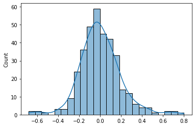

```python
# Plot histogram of residuals
sns.histplot(residuals, kde=True)
```

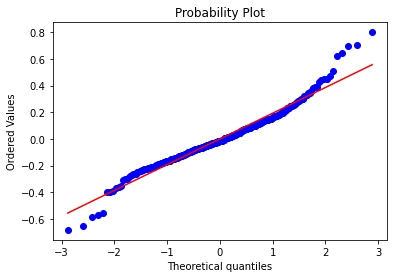

```python
# Plot q-q plot of residuals
import pylab
import scipy.stats as stats

stats.probplot(residuals, dist="norm", plot=pylab)
plt.show()
```

**Observations:**

### Check the performance of the model on the train and test data set

#### **Question 8:** Write your observations by comparing model performance of train and test dataset (2 Marks)

```python
# RMSE
def rmse(predictions, targets):
    return np.sqrt(((targets - predictions) ** 2).mean())


# MAPE
def mape(predictions, targets):
    return np.mean(np.abs((targets - predictions)) / targets) * 100


# MAE
def mae(predictions, targets):
    return np.mean(np.abs((targets - predictions)))


# Model Performance on test and train data
def model_pref(olsmodel, x_train, x_test):

    # In-sample Prediction
    y_pred_train = olsmodel.predict(x_train)
    y_observed_train = y_train

    # Prediction on test data
    y_pred_test = olsmodel.predict(x_test)
    y_observed_test = y_test

    print(
        pd.DataFrame(
            {
                "Data": ["Train", "Test"],
                "RMSE": [
                    rmse(y_pred_train, y_observed_train),
                    rmse(y_pred_test, y_observed_test),
                ],
                "MAE": [
                    mae(y_pred_train, y_observed_train),
                    mae(y_pred_test, y_observed_test),
                ],
                "MAPE": [
                    mape(y_pred_train, y_observed_train),
                    mape(y_pred_test, y_observed_test),
                ],
            }
        )
    )


# Checking model performance
model_pref(model2, X_train, X_test)
```

```
    Data      RMSE       MAE      MAPE
0  Train  0.195504  0.143686  4.981813
1   Test  0.198045  0.151284  5.257965
```

**Observations:**

- The RMSE on the test set is almost identical to that on the training set, which is what we want.
- The MAE and MAPE on the test set have a bigger difference to the ones on the train set, still not a big difference and similar enough.
- Our model seems to be generalizing really well, as the performance on test set yields similar results to training sets. If it was overfitting the difference would be bigger since it wouldn't generalize enough but fit the traiing set only. It is not underfitting error.
- The error on the test set is over 5.25%, we can try reducing it.

#### Apply cross validation to improve the model and evaluate it using different evaluation metrics

#### **Question 9:** Apply the cross validation technique to improve the model and evaluate it using different evaluation metrics. (1 Mark)

```python
# import the required function

from sklearn.model_selection import cross_val_score

# build the regression model and cross-validate
linearregression = LinearRegression()

cv_Score11 = cross_val_score(linearregression, X_train, y_train, cv = 10)
cv_Score12 = cross_val_score(linearregression, X_train, y_train, cv = 10, scoring = 'neg_mean_squared_error')


print("RSquared: %0.3f (+/- %0.3f)" % (cv_Score11.mean(), cv_Score11.std() * 2))
print("Mean Squared Error: %0.3f (+/- %0.3f)" % (-1*cv_Score12.mean(), cv_Score12.std() * 2))
```

```
RSquared: 0.729 (+/- 0.232)
Mean Squared Error: 0.041 (+/- 0.023)
```

**Observations**

We may want to reiterate the model building process again with new features or better feature engineering to increase the R-squared and decrease the MSE on cross validation.

#### **Question 10:** Get model Coefficients in a pandas dataframe with column 'Feature' having all the features and column 'Coefs' with all the corresponding Coefs. Write the regression equation. (2 Marks)

```python
coef = pd.DataFrame()
coef["Feature"]=["const", "CRIM", "CHAS", "NOX", "RM", "DIS", "RAD", "PTRATIO", "LSTAT"]
coef["Coefs"]=np.array(model2.params)
coef.set_index('Feature')
print(coef)
```

```
   Feature     Coefs
0    const  4.649386
1     CRIM -0.012500
2     CHAS  0.119773
3      NOX -1.056225
4       RM  0.058907
5      DIS -0.044069
6      RAD  0.007848
7  PTRATIO -0.048504
8    LSTAT -0.029277
```

```python
# Let us write the equation of the fit
Equation = "log (Price) ="
print(Equation, end='\t')
for i in range(len(coef)):
    print('(', coef["Coefs"][i], ') * ', coef["Feature"][i], end = ' ')
    if(i<len(coef)-1):
        print("+", end=" ")
```

[output not shown]